# Homework 3

Data Science

Due noon October 16, 2019

```r
library(tidyverse)
```

# Question 1

## Load data

```r
drg<-read.csv("C:\\Users\\wenyu\\OneDrive\\Desktop\\Data Science\\DRG_data.csv")
head(drg)
```

|  | DRG.Definition | Provider.Id | Provider.Name | Provider.Street.Address | Provider.City | Provider.State | Provider.Zip.Code | Hospital.Referral.Region.Description | Total.Discharges | Average.Covered.Charges | Average.Total.Payments | Average.Medicare.Payments |
| --- | --- | --- | --- | --- | --- | --- | --- | --- | --- | --- | --- | --- |
| 1 | 039 - EXTRACRANIAL PROCEDURES W/O CC/MCC | 10001 | SOUTHEAST ALABAMA MEDICAL CENTER | 1108 ROSS CLARK CIRCLE | DOTHAN | AL | 36301 | AL - Dothan | 91 | 32963.07 | 5777.24 | 4763.73 |
| 2 | 039 - EXTRACRANIAL PROCEDURES W/O CC/MCC | 10005 | MARSHALL MEDICAL CENTER SOUTH | 2505 U S HIGHWAY 431 NORTH | BOAZ | AL | 35957 | AL - Birmingham | 14 | 15131.85 | 5787.57 | 4976.71 |
| 3 | 039 - EXTRACRANIAL PROCEDURES W/O CC/MCC | 10006 | ELIZA COFFEE MEMORIAL HOSPITAL | 205 MARENGO STREET | FLORENCE | AL | 35631 | AL - Birmingham | 24 | 37560.37 | 5434.95 | 4453.79 |
| 4 | 039 - EXTRACRANIAL PROCEDURES W/O CC/MCC | 10011 | ST VINCENT'S EAST | 50 MEDICAL PARK EAST DRIVE | BIRMINGHAM | AL | 35235 | AL - Birmingham | 25 | 13998.28 | 5417.56 | 4129.16 |
| 5 | 039 - EXTRACRANIAL PROCEDURES W/O CC/MCC | 10016 | SHELBY BAPTIST MEDICAL CENTER | 1000 FIRST STREET NORTH | ALABASTER | AL | 35007 | AL - Birmingham | 18 | 31633.27 | 5658.33 | 4851.44 |
| 6 | 039 - EXTRACRANIAL PROCEDURES W/O CC/MCC | 10023 | BAPTIST MEDICAL CENTER SOUTH | 2105 EAST SOUTH BOULEVARD | MONTGOMERY | AL | 36116 | AL - Montgomery | 67 | 16920.79 | 6653.80 | 5374.14 |

# Question 2

## Make a single plot with boxplots of the average medicare payments by DRG code. What do you notice from the plots?

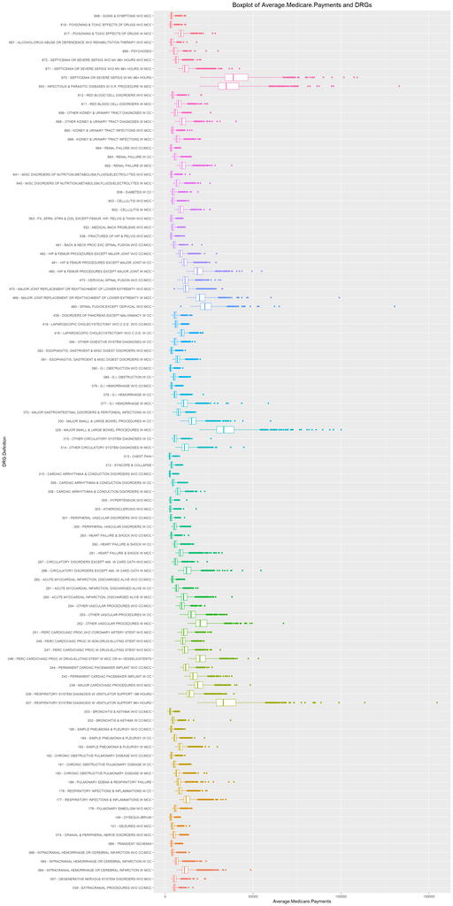

```r
ggplot(data=drg,aes(DRG.Definition,Average.Medicare.Payments,col=DRG.Definition),xlab="DRG code", ylab="Average.Medicare.Payments")+
  ggtitle("Boxplot of Average.Medicare.Payments and DRGs")+
  geom_boxplot()+
  theme(axis.text = element_text(size = 8),legend.position="none",plot.title = element_text(size=15,hjust = 0.5))+
  coord_flip()
```

The boxplot shows that the majority average medicare payments is between 0 to 25000, while there are also some codes with the lower quantile above 25000, such as 207,329, 853 and 870.

# Question 3

## Draw a boxplot of Average.Total.Payments and DRGs

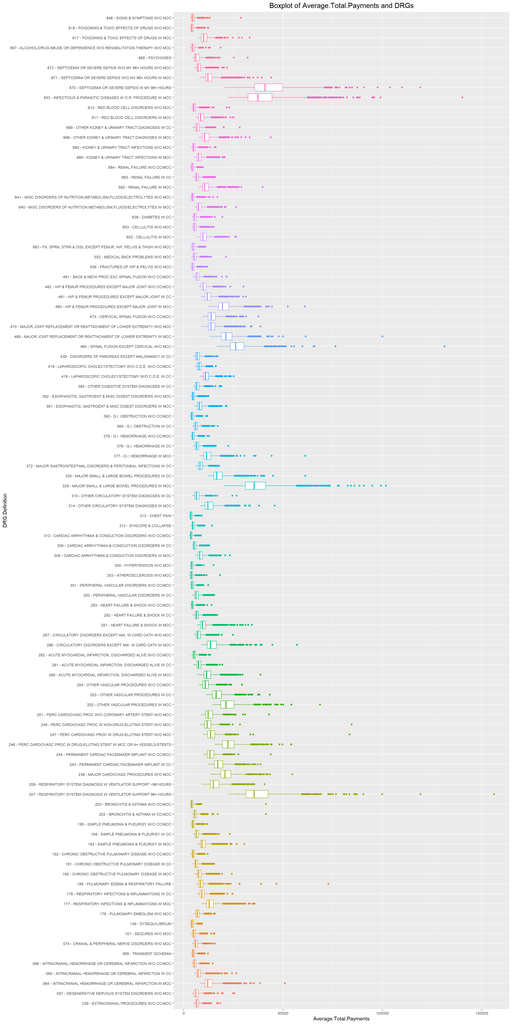

```r
ggplot(data=drg,aes(DRG.Definition,Average.Total.Payments,col=DRG.Definition),xlab="DRG code", ylab="Average.Total.Payments")+
  ggtitle("Boxplot of Average.Total.Payments and DRGs")+
  geom_boxplot()+
  theme(axis.text = element_text(size = 8),legend.position="none",plot.title = element_text(size=15,hjust = 0.5)) +
  coord_flip()
```

The distribution of DRG codes are similar to question 2 plot with higher statistics for each code. Because it includes the part paying for by the patient.

# Question 4

```r
mydata<-drg %>%
  select(DRG.Definition,Provider.Id,Provider.State,Average.Medicare.Payments) %>%
  spread(DRG.Definition, Average.Medicare.Payments)
```

# Question 5

## Make a function to calculate the mean, median, and standard deviation of the average medicare payments for each DRG code column.

```r
code<-distinct(drg,DRG.Definition)
calc<-function(x){
  c<-drg %>%
    filter(DRG.Definition==x) %>%
    group_by(DRG.Definition) %>%
    summarise(mean=mean(Average.Medicare.Payments),
              median=median(Average.Medicare.Payments),
              sd=sd(Average.Medicare.Payments))
  c
}

## Use for loop
g<-NULL
for(i in code$DRG.Definition){
  g<-bind_rows(g,calc(i))
}

## make the function to figure out the max and min of these statistics.
mi<-function(x){
  a<-g %>%
  summarise(max_name=DRG.Definition[which.max(x)],
            max_value=max(x),
            min_name=DRG.Definition[which.min(x)],
            min_value=min(x))
a
}
max_min<-bind_rows(mi(g$mean),mi(g$median),mi(g$sd))
max_min
```

| max_name | max_value | min_name | min_value |
| --- | --- | --- | --- |
| 870 - SEPTICEMIA OR SEVERE SEPSIS W MV 96+ HOURS | 41899.43 | 310 - CARDIAC ARRHYTHMIA & CONDUCTION DISORDERS W/O CC/MCC | 2876.0156 |
| 870 - SEPTICEMIA OR SEVERE SEPSIS W MV 96+ HOURS | 38789.43 | 313 - CHEST PAIN | 2587.4250 |
| 870 - SEPTICEMIA OR SEVERE SEPSIS W MV 96+ HOURS | 11766.81 | 310 - CARDIAC ARRHYTHMIA & CONDUCTION DISORDERS W/O CC/MCC | 880.6649 |

870 - SEPTICEMIA OR SEVERE SEPSIS W MV 96+ HOURS has the max mean, median, and sd which are 41899.43,38789.43 and 11766.81. 310 - CARDIAC ARRHYTHMIA & CONDUCTION DISORDERS W/O CC/MCC has the minimum mean value of 2876.016 and sd of 880.665, while 313 - CHEST PAIN has the minimum median at 2587.425.

## Question 6

## # use apply to calculate the mean, median, and standard deviation of the average medicare payments for each DRG code column

```r
applycal<-
  code$DRG.Definition %>%
  lapply(FUN = calc)  %>%
  bind_rows()
applycal
```

| DRG.Definition | mean | median | sd |
| --- | --- | --- | --- |
| 039 - EXTRACRANIAL PROCEDURES W/O CC/MCC | 5555.838 | 5269.280 | 1236.0634 |
| 057 - DEGENERATIVE NERVOUS SYSTEM DISORDERS W/O MCC | 5701.677 | 5104.780 | 1973.6201 |
| 069 - TRANSIENT ISCHEMIA | 3952.275 | 3627.465 | 1094.6828 |
| 064 - INTRACRANIAL HEMORRHAGE OR CEREBRAL INFARCTION W MCC | 12112.849 | 10956.160 | 3702.0478 |
| 065 - INTRACRANIAL HEMORRHAGE OR CEREBRAL INFARCTION W CC | 6781.502 | 6167.510 | 1979.4828 |
| 066 - INTRACRANIAL HEMORRHAGE OR CEREBRAL INFARCTION W/O CC/MCC | 4469.204 | 4079.575 | 1271.8522 |
| 074 - CRANIAL & PERIPHERAL NERVE DISORDERS W/O MCC | 5238.579 | 4815.660 | 1542.4021 |
| 101 - SEIZURES W/O MCC | 4452.601 | 4012.660 | 1379.4840 |
| 149 - DYSEQUILIBRIUM | 3440.677 | 3145.555 | 1076.0331 |
| 176 - PULMONARY EMBOLISM W/O MCC | 6077.949 | 5644.930 | 1505.4190 |

[output cut: 90 more lines]

## find the max and min value of each colomn

```r
max_min<-bind_rows(mi(g$mean),mi(g$median),mi(g$sd))
max_min
```

| max_name | max_value | min_name | min_value |
| --- | --- | --- | --- |
| 870 - SEPTICEMIA OR SEVERE SEPSIS W MV 96+ HOURS | 41899.43 | 310 - CARDIAC ARRHYTHMIA & CONDUCTION DISORDERS W/O CC/MCC | 2876.0156 |
| 870 - SEPTICEMIA OR SEVERE SEPSIS W MV 96+ HOURS | 38789.43 | 313 - CHEST PAIN | 2587.4250 |
| 870 - SEPTICEMIA OR SEVERE SEPSIS W MV 96+ HOURS | 11766.81 | 310 - CARDIAC ARRHYTHMIA & CONDUCTION DISORDERS W/O CC/MCC | 880.6649 |

## use map to calculate the mean, median, and standard deviation of the average medicare payments for each DRG code column.

```r
mapcal<-map(code$DRG.Definition,calc)%>% bind_rows()
mapcal
```

| DRG.Definition | mean | median | sd |
| --- | --- | --- | --- |
| 039 - EXTRACRANIAL PROCEDURES W/O CC/MCC | 5555.838 | 5269.280 | 1236.0634 |
| 057 - DEGENERATIVE NERVOUS SYSTEM DISORDERS W/O MCC | 5701.677 | 5104.780 | 1973.6201 |
| 069 - TRANSIENT ISCHEMIA | 3952.275 | 3627.465 | 1094.6828 |
| 064 - INTRACRANIAL HEMORRHAGE OR CEREBRAL INFARCTION W MCC | 12112.849 | 10956.160 | 3702.0478 |
| 065 - INTRACRANIAL HEMORRHAGE OR CEREBRAL INFARCTION W CC | 6781.502 | 6167.510 | 1979.4828 |
| 066 - INTRACRANIAL HEMORRHAGE OR CEREBRAL INFARCTION W/O CC/MCC | 4469.204 | 4079.575 | 1271.8522 |
| 074 - CRANIAL & PERIPHERAL NERVE DISORDERS W/O MCC | 5238.579 | 4815.660 | 1542.4021 |
| 101 - SEIZURES W/O MCC | 4452.601 | 4012.660 | 1379.4840 |
| 149 - DYSEQUILIBRIUM | 3440.677 | 3145.555 | 1076.0331 |
| 176 - PULMONARY EMBOLISM W/O MCC | 6077.949 | 5644.930 | 1505.4190 |

[output cut: 90 more lines]

## find the max and min value of each colomn

```r
max_min<-bind_rows(mi(g$mean),mi(g$median),mi(g$sd))
max_min
```

| max_name | max_value | min_name | min_value |
| --- | --- | --- | --- |
| 870 - SEPTICEMIA OR SEVERE SEPSIS W MV 96+ HOURS | 41899.43 | 310 - CARDIAC ARRHYTHMIA & CONDUCTION DISORDERS W/O CC/MCC | 2876.0156 |
| 870 - SEPTICEMIA OR SEVERE SEPSIS W MV 96+ HOURS | 38789.43 | 313 - CHEST PAIN | 2587.4250 |
| 870 - SEPTICEMIA OR SEVERE SEPSIS W MV 96+ HOURS | 11766.81 | 310 - CARDIAC ARRHYTHMIA & CONDUCTION DISORDERS W/O CC/MCC | 880.6649 |

# Question 7

## Make a function to return the provider in each state with the most expensive average medicare payments for the DRG code 870 - SEPTICEMIA OR SEVERE SEPSIS W MV 96+ HOURS.

```r
state<-function(x){
  x %>%
    filter(DRG.Definition=="870 - SEPTICEMIA OR SEVERE SEPSIS W MV 96+ HOURS")%>%
    select(Provider.State,Provider.Name,Average.Medicare.Payments) %>%
    arrange(desc(Average.Medicare.Payments)) %>%
    head(n = 1)
}

drg %>%
  group_by(Provider.State) %>%
  do(state(.))
```

| Provider.State | Provider.Name | Average.Medicare.Payments |
| --- | --- | --- |
| AK | PROVIDENCE ALASKA MEDICAL CENTER | 50947.54 |
| AL | UNIVERSITY OF ALABAMA HOSPITAL | 45050.17 |
| AR | UAMS MEDICAL CENTER | 44336.11 |
| AZ | FLAGSTAFF MEDICAL CENTER | 70056.75 |
| CA | STANFORD HOSPITAL | 109303.21 |
| CO | UNIVERSITY OF COLORADO HOSPITAL ANSCHUTZ INPATIENT | 62348.66 |
| CT | YALE-NEW HAVEN HOSPITAL | 71646.94 |
| DC | GEORGETOWN UNIVERSITY HOSPITAL | 67276.27 |
| DE | CHRISTIANA CARE HEALTH SERVICES, INC. | 45224.12 |
| FL | JACKSON MEMORIAL HOSPITAL | 62378.33 |

[output cut: 38 more lines]

## Find the most expensive provider in New York.

```r
drg %>%
  group_by(Provider.State) %>%
  filter(Provider.State=="NY") %>%
  do(state(.))
```

| Provider.State | Provider.Name | Average.Medicare.Payments |
| --- | --- | --- |
| NY | WESTCHESTER MEDICAL CENTER | 107456.2 |

The most expensive provider in New York is WESTCHESTER MEDICAL CENTER with a payment of 107456.2.

## My function to the name of the most expensive provider in New York for other codes.

```r
expen<-function(x){
  expensive<-drg %>%
  filter(DRG.Definition==x)%>%
  group_by(Provider.State) %>%
  summarise(name=Provider.Name[which.max(Average.Medicare.Payments)],
            payment=max(Average.Medicare.Payments)) %>%
  filter(Provider.State=="NY")
expensive
}
expen("039 - EXTRACRANIAL PROCEDURES W/O CC/MCC")
```

| Provider.State | name | payment |
| --- | --- | --- |
| NY | LONG ISLAND JEWISH MEDICAL CENTER | 13280.54 |

The most expensive provider of 039 - EXTRACRANIAL PROCEDURES W/O CC/MCC in New York is LONG ISLAND JEWISH MEDICAL CENTER with a payment of 13280.54.

```r
expen("313 - CHEST PAIN")
```

| Provider.State | name | payment |
| --- | --- | --- |
| NY | LINCOLN MEDICAL & MENTAL HEALTH CENTER | 7255.94 |

The most expensive provider of 313 - CHEST PAIN in New York is LINCOLN MEDICAL & MENTAL HEALTH CENTER with a payment of 7255.94.